# Homework 2

Sinclair Stockard

September 13, 2018

## Question 1a

```r
data_info <- (read.table('TCGA_brca_tcga_info.txt', quote = "", header=T, sep='\t'))

data_rna <- (read.table('TCGA_brca_tcga_RNAseq.txt', header=T, sep='\t',row.names = 1))
```

## Question 1b

```r
dim(data_info)
```

```
## [1] 1003   47
```

```r
dim(data_rna)
```

```
## [1] 17881  1003
```

## Question 1c

Using the str command, we can see there are 1003 sample IDs for only 997 patient IDs. It is difficult to determine why some patients had multiple samples without doing further research on the barcodes for the TCGA dataset. Sample IDs from the same patient end with “01” or “06”" These differences in nomenclature represent metastatic vs primary tumor samples.

```r
str(data_info)
```

```
## 'data.frame':    1003 obs. of  47 variables:
##  $ SAMPLE.ID                                                                                  : Factor w/ 1003 levels "TCGA.5T.A9QA.01",..: 1 2 3 4 5 6 7 8 9 10 ...
##  $ PATIENT.ID                                                                                 : Factor w/ 997 levels "TCGA-5T-A9QA",..: 1 2 3 4 5 6 7 8 9 10 ...
##  $ Adjuvant.Postoperative.Pharmaceutical.Therapy.Administered.Indicator                       : Factor w/ 4 levels "","[Unknown]",..: 2 1 1 1 1 1 1 1 1 1 ...
##  $ American.Joint.Committee.on.Cancer.Publication.Version.Type                                : Factor w/ 5 levels "","4th","5th",..: 5 4 4 4 4 4 4 4 4 4 ...
##  $ American.Joint.Committee.on.Cancer.Tumor.Stage.Code                                        : Factor w/ 13 levels "T1","T1a","T1b",..: 5 4 5 4 5 5 5 5 8 5 ...
##  $ American.Joint.Committee.on.Cancer.Metastasis.Stage.Code                                   : Factor w/ 4 levels "cM0 (i+)","M0",..: 4 2 2 2 2 2 2 2 2 2 ...
##  $ Birth.from.Initial.Pathologic.Diagnosis.Date                                               : int  -19031 -25833 -21793 -20717 -19731 -22380 -14595 -19250 -14383 -20048 ...
##  $ CNA                                                                                        : num  0.413 0.000802 0.247 0.213 0.202 ...
##  $ Death.from.Initial.Pathologic.Diagnosis.Date                                               : int  NA NA NA NA NA NA NA NA NA 967 ...
##  $ Diagnosis.Age                                                                              : int  52 70 59 56 54 61 39 52 39 54 ...
##  $ Did.patient.start.adjuvant.postoperative.radiotherapy.                                     : Factor w/ 4 levels "","[Unknown]",..: 2 1 1 1 1 1 1 1 1 1 ...
##  $ Disease.Free..Months.                                                                      : num  0.39 8.51 14.4 43.4 48.1 14.3 47.2 20.9 13.7 NA ...
##  $ Disease.Free.Status                                                                        : Factor w/ 3 levels "","DiseaseFree",..: 2 2 2 2 2 2 2 2 2 1 ...
##  $ Disease.Surgical.Margin.Status                                                             : Factor w/ 5 levels "","[Unknown]",..: 2 4 5 4 4 4 4 4 4 5 ...
```

[output cut: 33 more lines]

## Question 1d

The column names are sample IDs, as they correspond to those in the “info” dataset. The row names are names of genes. Therefore, a given column represents all gene expression data for a single sample. Rows represent expression of a single gene across all samples.

```r
data_rna[1:10,1:10]
```

```
##          TCGA.AR.A1AR.01 TCGA.BH.A1EO.01 TCGA.BH.A1ES.06 TCGA.BH.A1ES.01
## A1BG                42.2            85.8          7763.4           119.4
## A1BG.AS1            66.2           118.8           130.3           232.1
## A1CF                 0.2             0.0           123.8             0.0
## A2M              11852.1         17003.0         19163.5          9085.9
## A2ML1               30.9             9.7             4.3             1.6
## A4GALT              96.6           477.2          4142.5            97.5
## A4GNT                1.2             1.1             0.4             0.8
## AAAS               367.0           392.5           808.5           771.3
## AACS               525.2           485.2           743.3           912.3
## AACSP1               8.7             0.0             1.4             0.0
##          TCGA.BH.A1ET.01 TCGA.BH.A1EU.01 TCGA.BH.A1EV.01 TCGA.BH.A1EW.01
## A1BG               123.0            67.0           151.9            94.4
## A1BG.AS1           161.2           124.9           150.5           164.6
## A1CF                 0.0             0.0             1.2             0.0
## A2M              13017.5         24327.7          7304.5         14461.1
## A2ML1                0.4             1.7           145.1             3.2
## A4GALT              87.0           152.8           234.0          1024.4
## A4GNT                0.2             0.8             1.9             0.4
## AAAS               745.5           814.1           818.1           525.5
## AACS              1208.5           753.6           578.2           564.3
## AACSP1               0.2             0.0             0.0             0.0
##          TCGA.BH.A1F0.01 TCGA.C8.A1HF.01
## A1BG                43.3            28.7
## A1BG.AS1           119.8            84.0
## A1CF                 0.0             0.3
## A2M              22390.7         15950.0
## A2ML1                3.9             3.3
## A4GALT             303.0           101.0
## A4GNT                1.3             0.6
## AAAS               400.7           822.7
## AACS               770.0           698.5
## AACSP1               2.4             0.0
```

## Question 2

Gene expression looks similar among samples.

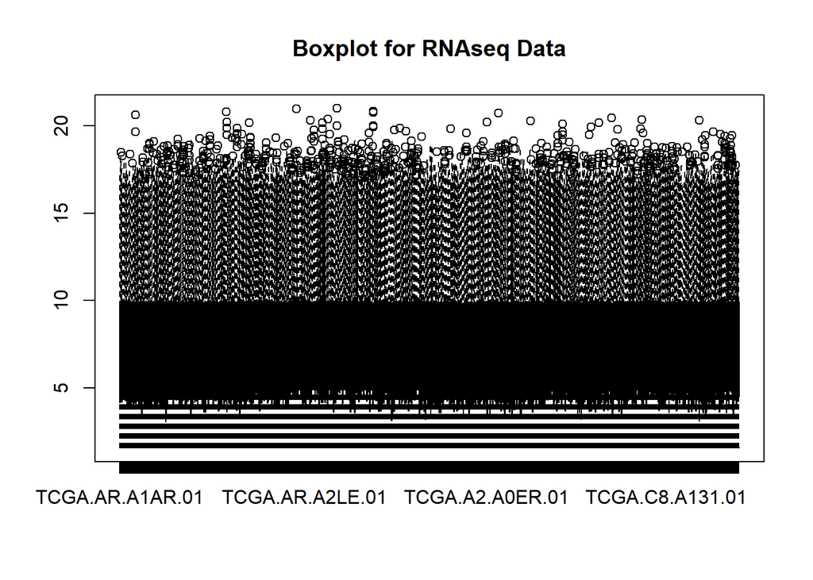

```r
data_rna <- log2(3 + data_rna)

boxplot(data_rna, main = "Boxplot for RNAseq Data")
```

## Question 3a

10.67% of the variance is explained by component 1, and 8.34% is explained by component two. Together, these component account for 19.01% of the variance. The summary only displays the first 10 components.

```r
rna_matrix <- as.matrix(data_rna)
t_rna_matrix <- t(rna_matrix)
t_rna_matrix <- t_rna_matrix[, apply(t_rna_matrix,2,var)!=0]
pca_rna <- prcomp(t_rna_matrix, center = TRUE, scale. = TRUE, rank = 10)

summary(pca_rna)
```

```
## Importance of first k=10 (out of 1003) components:
##                            PC1      PC2      PC3      PC4      PC5
## Standard deviation     43.6599 38.60241 33.88756 23.54418 20.91084
## Proportion of Variance  0.1067  0.08341  0.06428  0.03103  0.02447
## Cumulative Proportion   0.1067  0.19010  0.25438  0.28540  0.30988
##                             PC6      PC7      PC8      PC9     PC10
## Standard deviation     19.88048 17.73734 16.86861 15.64134 14.11342
## Proportion of Variance  0.02212  0.01761  0.01593  0.01369  0.01115
## Cumulative Proportion   0.33200  0.34961  0.36554  0.37923  0.39038
```

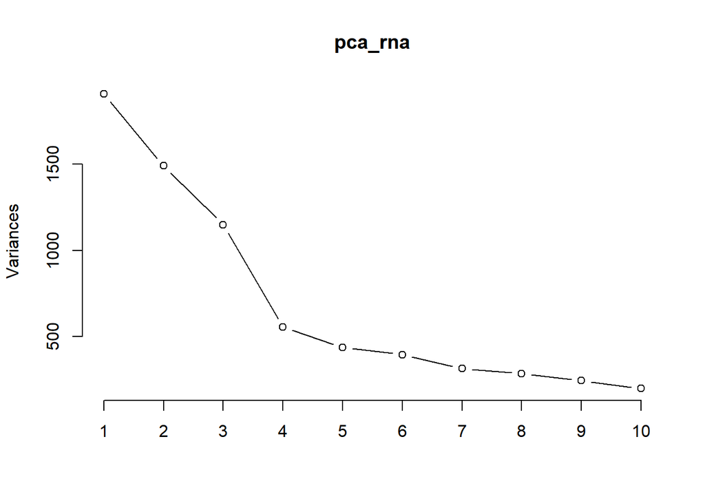

```r
plot(pca_rna, type = 'lines')
```

## Question 3b

There plot below suggests that there are at least 2 possible subtypes of breast cancer.

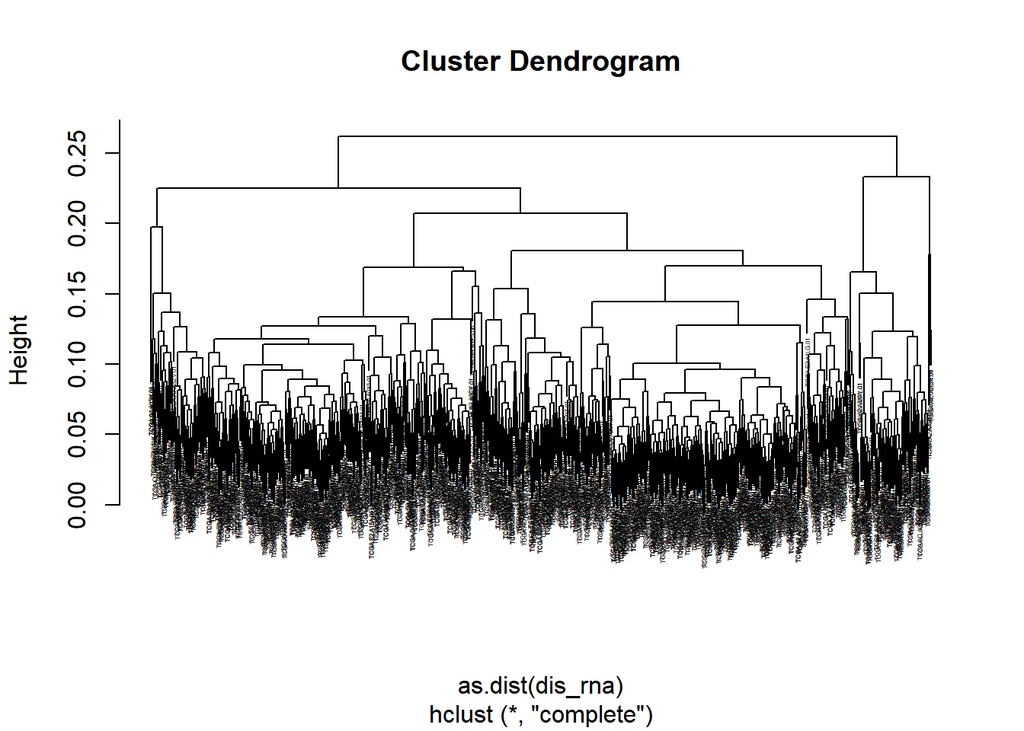

```r
sim_rna <- cor(rna_matrix, method='pearson')
dis_rna <- (1.0 - sim_rna)
clu_rna <- hclust(as.dist(dis_rna))
plot(clu_rna, cex=0.25)
```

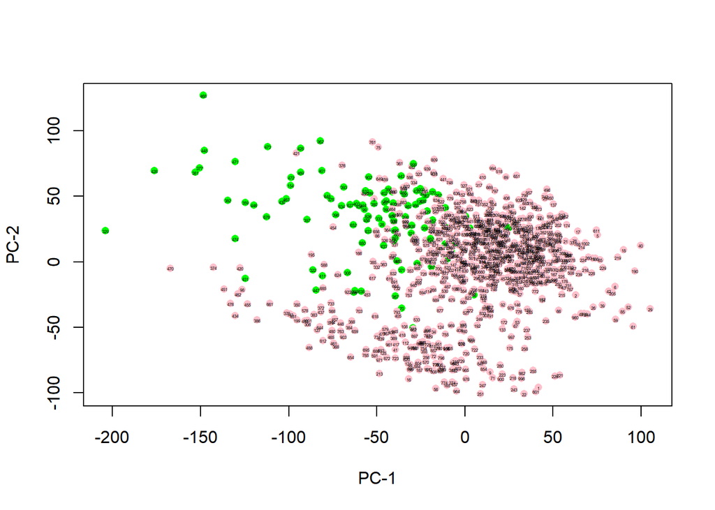

```r
grp2_rna <- cutree(clu_rna, 2)

x_t <- pca_rna$x
color2 <- c('pink', 'green')
plot(x_t[,1], x_t[,2], col=color2[grp2_rna], pch=16, xlab="PC-1", ylab="PC-2")
text(x_t[,1], x_t[,2], cex=0.25)
```

## Question 4a

It looks like there could be 4-6 subtypes from this cluster dendrogram.

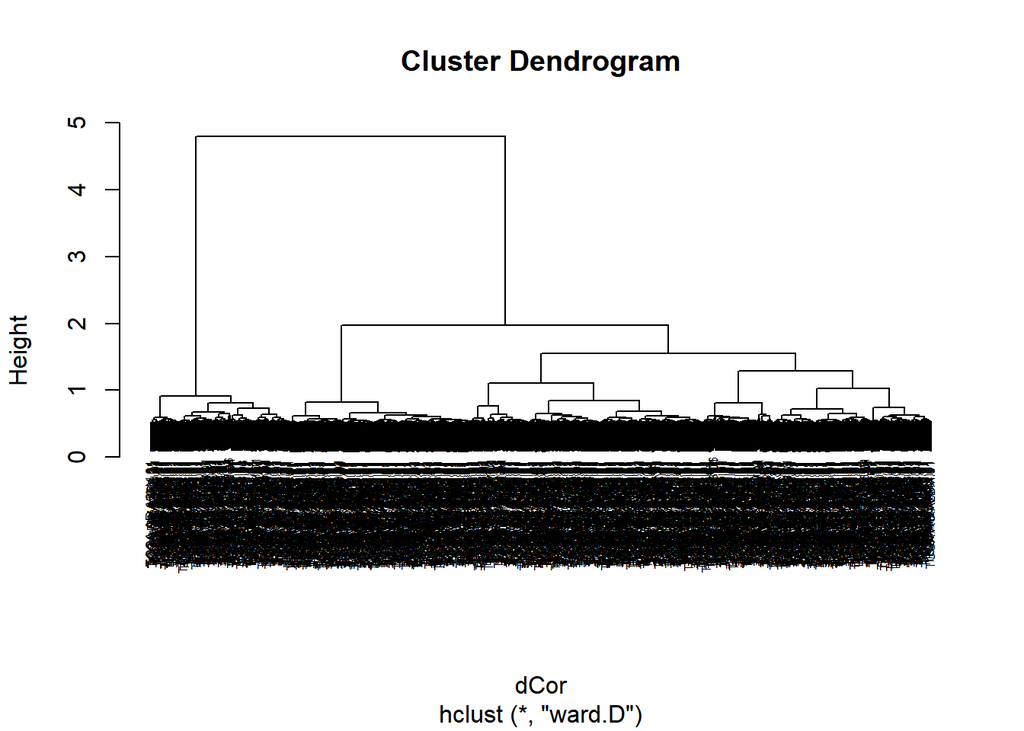

```r
dCor <- as.dist( (1-cor(rna_matrix)/2))

clu_RNA1 <- hclust(dCor, method='ward.D')

plot(clu_RNA1, cex=.50)
```

## Question 4b

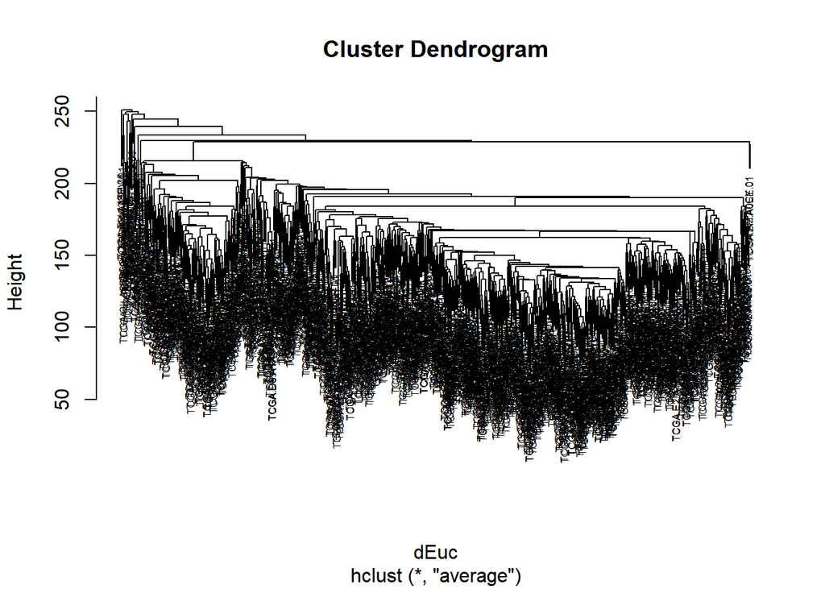

```r
dEuc <- dist(t(rna_matrix))

clu_RNA2 <- hclust(dEuc, method='average')

plot(clu_RNA2, cex=.50)
```

## Question 4c

The first method gives more useful results. It is harder to decipher the clusters using the Euclidian/average clustering method as there are less distance between the clusters.

## Question 5a

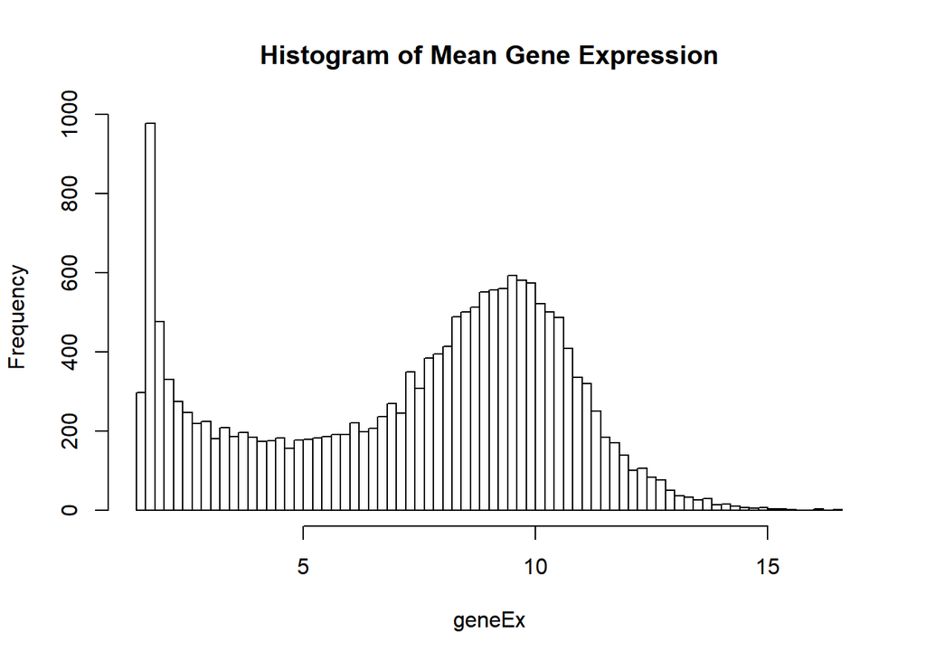

```r
geneEx <- rowMeans(rna_matrix)

hist(geneEx, breaks = 60, main = "Histogram of Mean Gene Expression")
```

## Question 5b

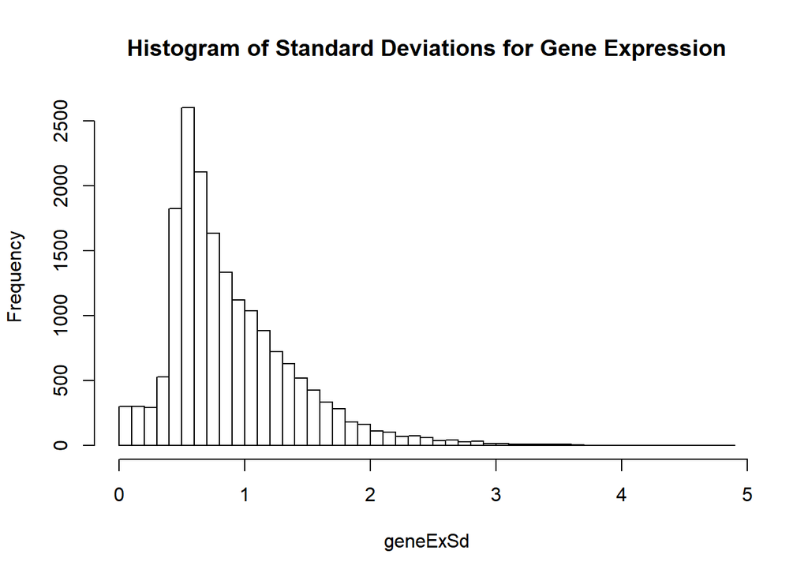

```r
geneExSd <- apply(rna_matrix,1,sd)

hist(geneExSd, breaks = 60, main = "Histogram of Standard Deviations for Gene Expression")
```

## Question 5c

The filtered dataset has 2340 genes. The mean cut off seems reasonable for this data set as it excludes genes that are expressed at low levels while keeping those that are being decently expressed. Limiting the data to genes with a standard deviation greater than 1 allows for focus on genes that could be differentially expressed among samples. However, these cut offs are arbitrary and depend largely on the project and analysis at hand.

```r
unfiltered <- row.names(rna_matrix)
mean_filter <- names(geneEx[geneEx <=7])
sd_filter <- names(geneExSd[geneExSd <=1])
filtered <- union(mean_filter,sd_filter)

final_filtered <- rna_matrix[setdiff(unfiltered,filtered),]

dim(final_filtered)
```

```
## [1] 2340 1003
```

## Question 5d

```r
library(ClassDiscovery)
```

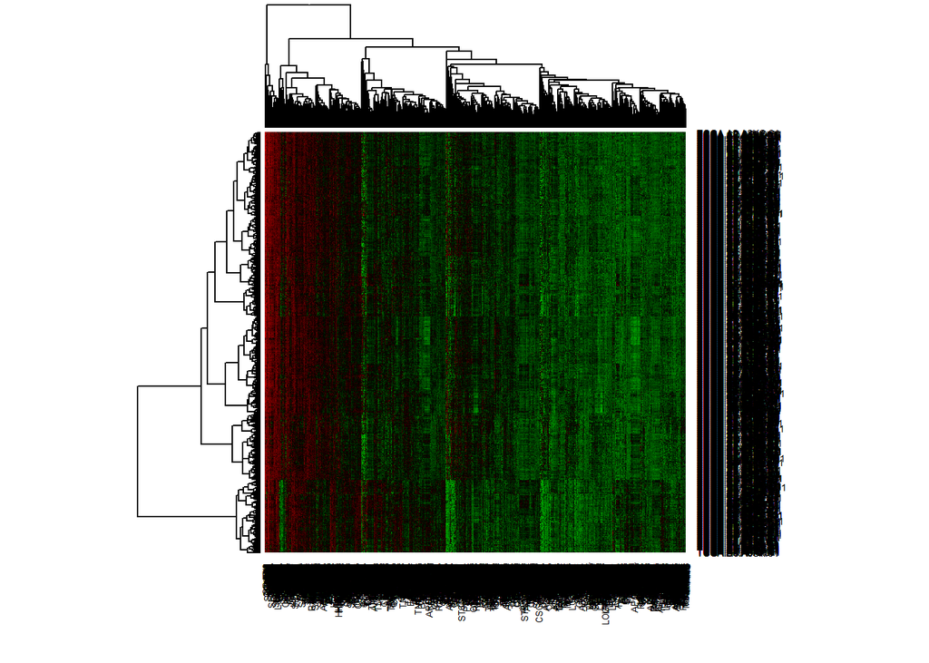

```r
filter_matrix <- as.matrix(final_filtered)

sc <- hclust(distanceMatrix(final_filtered, "pearson"),
               method="ward.D2")
gc <- hclust(distanceMatrix(t(final_filtered), "pearson"),
               method="ward.D2")
heatmap(t(final_filtered), col=redgreen(64),
        Rowv=as.dendrogram(sc))
```

## Question 6d

It would be useful to have a feature to log transform data within the app based on user input. It may also be helpful for the app to generate a heatmap of the data for the unfiltered and filtered datasets.